# Assignment10

Patrick Maloney

4/5/2020

## Sentiment Analysis

For this weeks assignment, I will be using two sentiment analysis dictionaries (Syuzhet and NRC) to analyze Jerome K. Jerome’s “Three Men in a Boat.”

The model for the code came from the reading in Chapter 2 of Julia Silge and David Robinson’s “Text Mining in R: A Tidy Approach” (2017).

```r
library(tidyverse)
library(gutenbergr)
library(tidytext)
library(syuzhet)
dict_syu <- get_sentiment_dictionary()
tail(dict_syu)
```

```
##          word value
## 10743  zenith  0.40
## 10744    zest  0.50
## 10745  zombie -0.25
## 10746 zombies -0.25
## 10747   false -0.60
## 10748    true  0.50
```

I have chosen to use the Jerome K. Jerome book “Three Men in a Boat.” This is a comedic novel set mostly on the Thames River in England in the late 19th century, about three friends on a boat trip. I will download this file from the gutenberg project using the gutenbergr library.

```r
jerome <- gutenberg_download(c(308), meta_fields = "title") %>%
  mutate(linenumber = row_number()) %>%
  ungroup() %>%
  unnest_tokens(word, text)
```

```
## Determining mirror for Project Gutenberg from http://www.gutenberg.org/robot/harvest
```

```
## Using mirror http://aleph.gutenberg.org
```

```r
jerome
```

```
## # A tibble: 68,017 x 4
##    gutenberg_id title               linenumber word
##           <int> <chr>                    <int> <chr>
##  1          308 Three Men in a Boat          1 three
##  2          308 Three Men in a Boat          1 men
##  3          308 Three Men in a Boat          1 in
##  4          308 Three Men in a Boat          1 a
##  5          308 Three Men in a Boat          1 boat
##  6          308 Three Men in a Boat          2 _to
##  7          308 Three Men in a Boat          2 say
##  8          308 Three Men in a Boat          2 nothing
##  9          308 Three Men in a Boat          2 of
## 10          308 Three Men in a Boat          2 the
## # ... with 68,007 more rows
```

```r
syuzhet <- jerome %>%
  inner_join(get_sentiment_dictionary()) %>%
  group_by(index = linenumber %/% 129) %>%
  summarise(sentiment = sum(value)) %>%
  mutate(method = "Syuzhet")
```

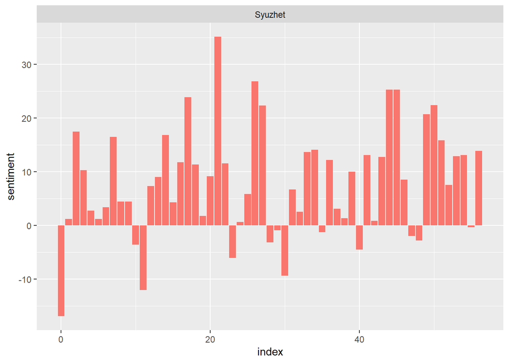

```r
syuzhet %>%
  ggplot(aes(index, sentiment, fill = method)) +
  geom_col(show.legend = FALSE) +
  facet_wrap(~method, ncol = 1, scales = "free_y")
```

As We can see above, the snetiment of the lines is overwhelmingly positive. I admit I am impressed by this, as the book speaks wryly about things such as illness and danger, and even includes some sarcasm, but the sentiment plot above manages to capture the positive expereince of the reader throughout the book.

Since this is a humorous book, and some scholars suggest that fear and humor are actually similar emotions, it will be interesting to look at which words in the book are associated with fear and how often they appear.

```r
nrc <- get_sentiments("nrc")

fear_words <- nrc %>% filter(sentiment == "fear")

jerome %>%
  inner_join(fear_words) %>%
  count(word, sort = TRUE)
```

```
## # A tibble: 335 x 2
##    word       n
##    <chr>  <int>
##  1 watch     21
##  2 lines     20
##  3 case      19
##  4 ill       17
##  5 bad       16
##  6 change    15
##  7 afraid    14
##  8 stroke    14
##  9 broken    13
## 10 mad       13
## # ... with 325 more rows
```

And for fun, since comedy is the theatre of the unexpected, lets look at words with the sentiment “surprise.”

```r
surprise_words <- nrc %>% filter(sentiment == "surprise")

jerome %>%
  inner_join(surprise_words) %>%
  count(word, sort = TRUE)
```

```
## # A tibble: 169 x 2
##    word         n
##    <chr>    <int>
##  1 good       108
##  2 young       58
##  3 trip        24
##  4 sweet       22
##  5 pleasant    21
##  6 suddenly    16
##  7 laugh       14
##  8 leave       14
##  9 lovely      14
## 10 shout       14
## # ... with 159 more rows
```